# Analysis of Pride and Prejudice

# Sentiment Analysis

The sentiment analysis will delve deeper into the emotional undercurrents, providing different levels of understanding of how these characters interact and the tone of those interactions.

## General Sentiment

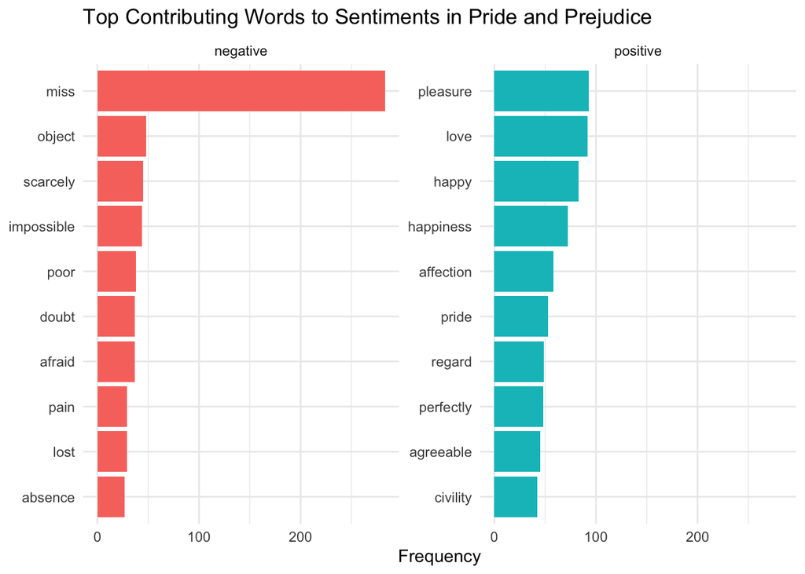

```r
# Get sentiment scores from the 'bing' lexicon
bing_sentiments <- get_sentiments("bing")

# Add a temporary index to preserve the order
tidy_text <- tidy_text %>%
  mutate(temp_index = row_number())

# Join words with sentiments
sentiment_scores <- tidy_text %>%
  inner_join(bing_sentiments, by = "word") %>%
  mutate(sentiment_score = ifelse(sentiment == "positive", 1, ifelse(sentiment == "negative", -1, 0)))

# Reassign the original index based on the temporary index
sentiment_scores <- sentiment_scores %>%
  arrange(temp_index) %>%
  mutate(index = temp_index) %>%
  select(-temp_index)  # Drop the temporary index after use


# Count the number of each word by sentiment
bing_word_counts <- sentiment_scores %>%
  group_by(word, sentiment) %>%
  summarise(count = n(), .groups = 'drop') %>%
  ungroup()

# Filter to top 10 words for each sentiment
bing_top_words <- bing_word_counts %>%
  group_by(sentiment) %>%
  top_n(10, count) %>%
  ungroup() %>%
  mutate(word = reorder(word, count))

# Plot: Faceted bar chart for each sentiment
facet_plot <- ggplot(bing_top_words, aes(x = word, y = count, fill = sentiment)) +
  geom_col(show.legend = FALSE) +
  facet_wrap(~sentiment, scales = "free_y") +
  labs(title = "Top Contributing Words to Sentiments in Pride and Prejudice",
       y = "Frequency", x = NULL) +
  coord_flip() +
  theme_minimal()

print(facet_plot)
```

Words expressing negative emotions such as “miss,” “object,” and “impossible” are common, suggesting themes of desire, obstacles, and challenges in the narrative.

In contrast, words expressing positive emotions such as “pleasure,” “love,” and “happy” emphasize the presence of moments of joy and love.